# Hrushikesh_DayanandaSagarCollegeOfEngineering_1DS19EC717

### Packages

```python
import pandas as pd
import matplotlib.pyplot as plt
import numpy as np
import seaborn as sns
import statsmodels.api as sm
import statsmodels.tsa.stattools as sts
from sklearn.metrics import mean_squared_log_error as rmsle
from statsmodels.tsa.seasonal import seasonal_decompose
from statsmodels.tsa.arima.model import ARIMA
from statsmodels.graphics.tsaplots import plot_acf, plot_pacf , plot_predict
from pmdarima.arima import auto_arima
import joblib

import warnings
warnings.filterwarnings("ignore")

plt.rcParams['figure.figsize'] = (20,15)
plt.rcParams['font.size'] = 20
```

### Loading the data

```python
data = pd.read_excel('Hackathon_Information_Data.xlsx',sheet_name = 'Data')
data.columns = ['Country','Date','Value']
data.Date = pd.to_datetime(data.Date)
data.head()
```

|  | Country | Date | Value |
| --- | --- | --- | --- |
| 0 | Canada | 2019-01-01 | 2.215572e+06 |
| 1 | Canada | 2019-02-01 | 2.090147e+06 |
| 2 | Canada | 2019-03-01 | 6.633213e+06 |
| 3 | Canada | 2019-04-01 | 2.067832e+06 |
| 4 | Canada | 2019-05-01 | 2.317593e+06 |

```python
countries = ['Canada','China','Germany','USA','Italy']
dates = pd.date_range(start = '2022-05-01' , periods = 15,freq = 'MS')

forecast_df = pd.DataFrame(
    columns=countries,
    index=dates)
forecast_df.head()
```

|  | Canada | China | Germany | USA | Italy |
| --- | --- | --- | --- | --- | --- |
| 2022-05-01 | NaN | NaN | NaN | NaN | NaN |
| 2022-06-01 | NaN | NaN | NaN | NaN | NaN |
| 2022-07-01 | NaN | NaN | NaN | NaN | NaN |
| 2022-08-01 | NaN | NaN | NaN | NaN | NaN |
| 2022-09-01 | NaN | NaN | NaN | NaN | NaN |

# Canada Country Analysis

### Data Preparation

```python
df_canada=data[data.Country == 'Canada'].drop('Country',axis = 1).set_index('Date').astype(int)
df_canada.head()
```

| Date | Value |
| --- | --- |
| 2019-01-01 | 2215572 |
| 2019-02-01 | 2090147 |
| 2019-03-01 | 6633213 |
| 2019-04-01 | 2067832 |
| 2019-05-01 | 2317592 |

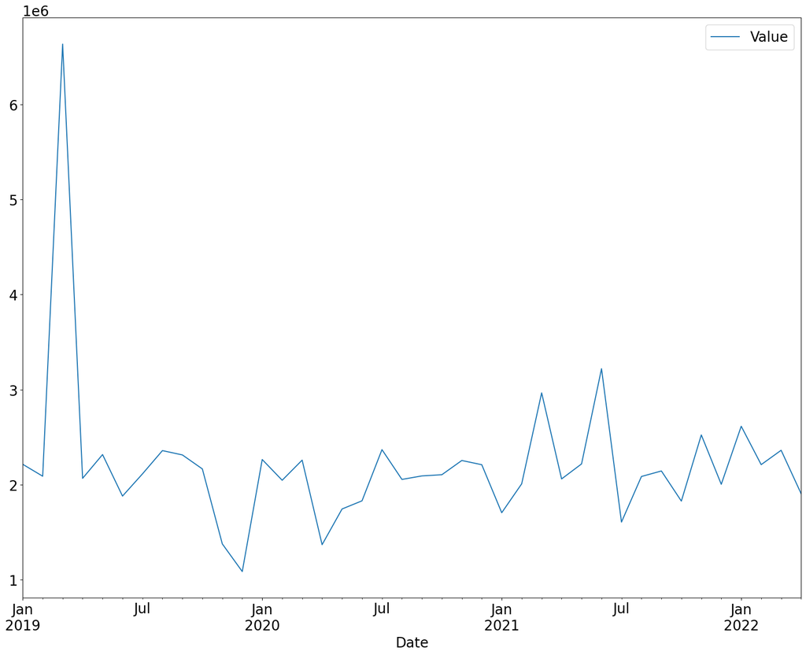

```python
df_canada.plot()
```

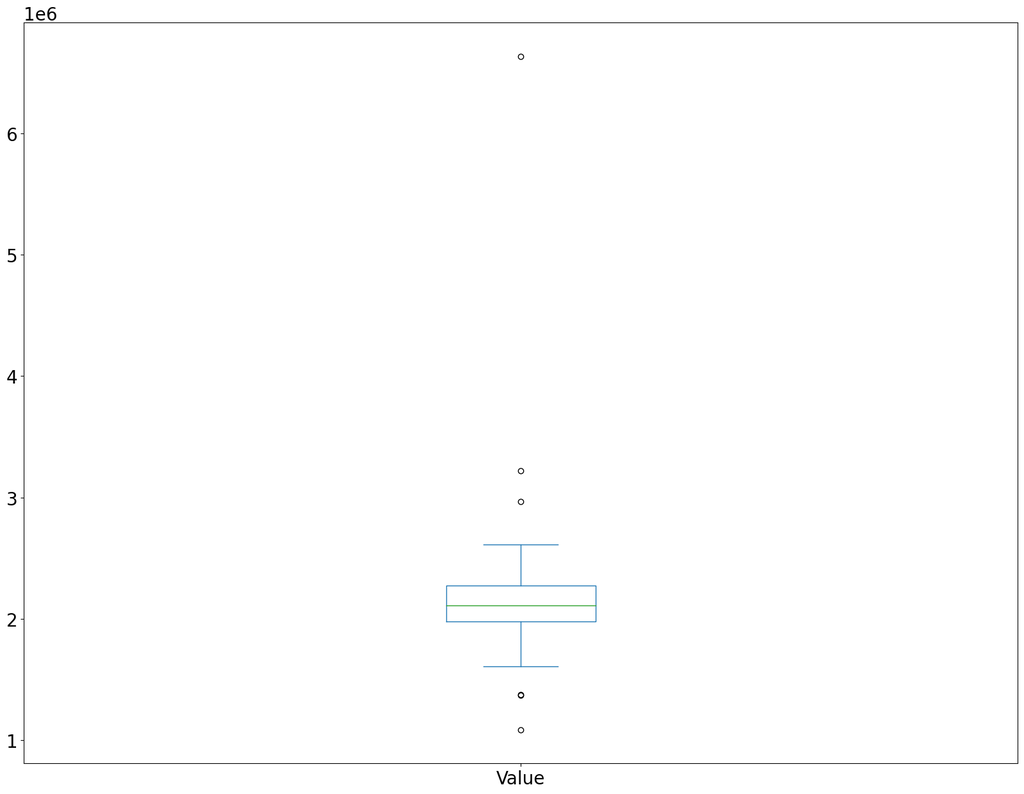

```python
df_canada['Value'].plot(kind = 'box')
```

```python
df_canada['Value'].sort_values(ascending = False).head(4)
```

```
Date
2019-03-01    6633213
2021-06-01    3220239
2021-03-01    2966347
2022-01-01    2615291
Name: Value, dtype: int32
```

```python
df_canada['Value'].quantile(q= [0.1 , 0.25  , 0.5 , 0.75 , 1])
```

```
0.10    1696387.2
0.25    1980668.0
0.50    2110186.5
0.75    2277570.0
1.00    6633213.0
Name: Value, dtype: float64
```

**We can see there is a hude difference between max and the 2nd max value which can also be seen as outlier in the boxplot** **Now we will replace that outlier with the 2nd max value in the column**

```python
df_canada['New_Value'] = df_canada['Value'].replace(6633213 , 3220239)
```

### Seasonal Decomposition Of Data

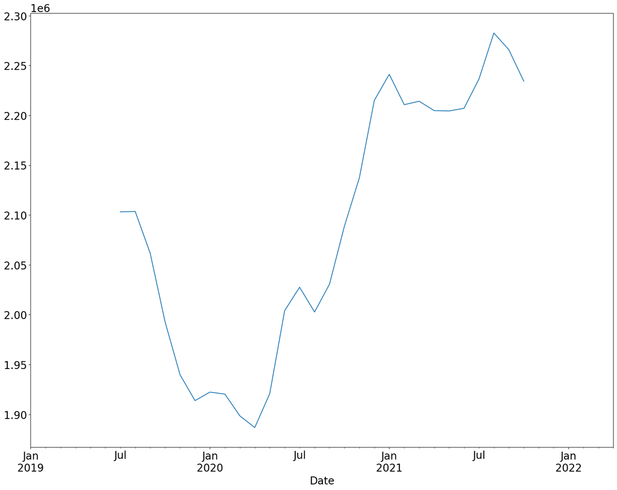

```python
# Since there is no seasonality in the data we use additive model
decomposition = seasonal_decompose(df_canada['New_Value'] , model = 'additive')

# Lets plot the trend
decomposition.trend.plot()
plt.show()
```

### Check For Stationarity :- A D-Fuller Test

```python
result = sts.adfuller(df_canada['New_Value'])
print(f'ADF Statistic : {result[0]}')
print(f'n_lags: {result[2]}')
print(f'p_value: {result[1]}')

for key , value in result[4].items():
    print('Critical Values :')
    print(f'{key} , {value}')
```

```
ADF Statistic : -6.173412645078009
n_lags: 0
p_value: 6.719672626793154e-08
Critical Values :
1% , -3.610399601308181
Critical Values :
5% , -2.939108945868946
Critical Values :
10% , -2.6080629651545038
```

**Since p_value < 0.05 We reject the Null Hypotheses that Data is Non-Stationary**  
**Therefore Data is Stationary**

### Auto Correlation Function

#### ACF is a statistical representation used to analyze the degree of similarity between a time series and a lagged version of itself.

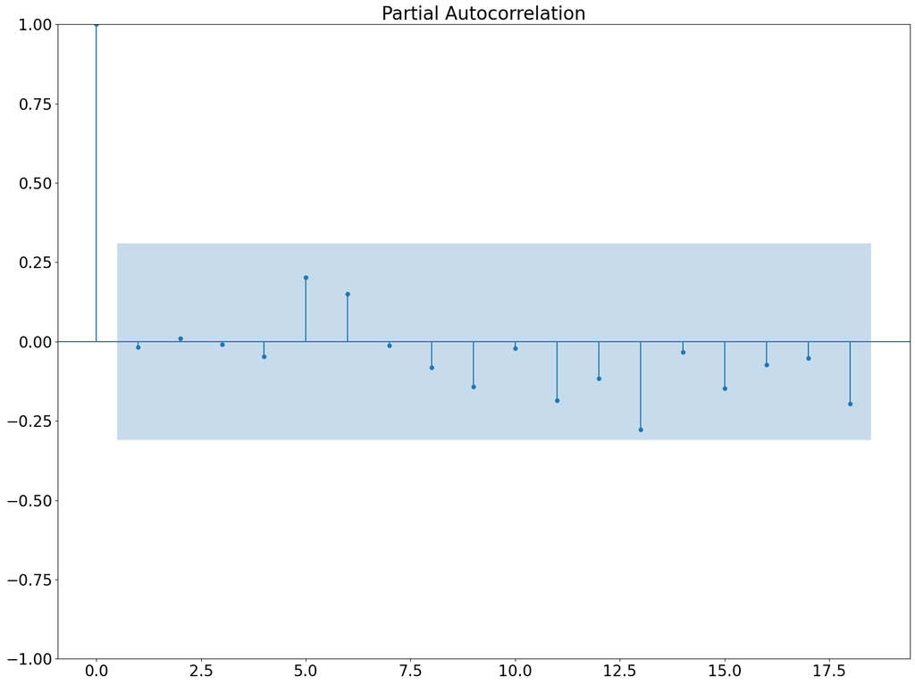

```python
plot_pacf(df_canada['New_Value'] , lags = 18)
plt.show()
```

**We can see that there is no possible degree of similarity.....Lets get the Return values**

### Creating Returns and Plotting ACF

#### Formula to calculate returns

#### $ Return_{t} = \frac{value_{t} - value_{t-1}}{value_{t-1}} * 100 $

```python
df_canada['Return'] = df_canada['New_Value'].pct_change(1).mul(100)
df_canada.head()
```

| Date | Value | New_Value | Return |
| --- | --- | --- | --- |
| 2019-01-01 | 2215572 | 2215572 | NaN |
| 2019-02-01 | 2090147 | 2090147 | -5.661066 |
| 2019-03-01 | 6633213 | 3220239 | 54.067585 |
| 2019-04-01 | 2067832 | 2067832 | -35.786381 |
| 2019-05-01 | 2317592 | 2317592 | 12.078351 |

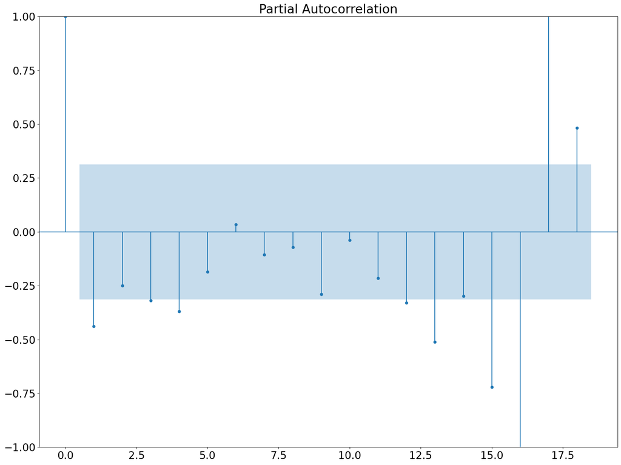

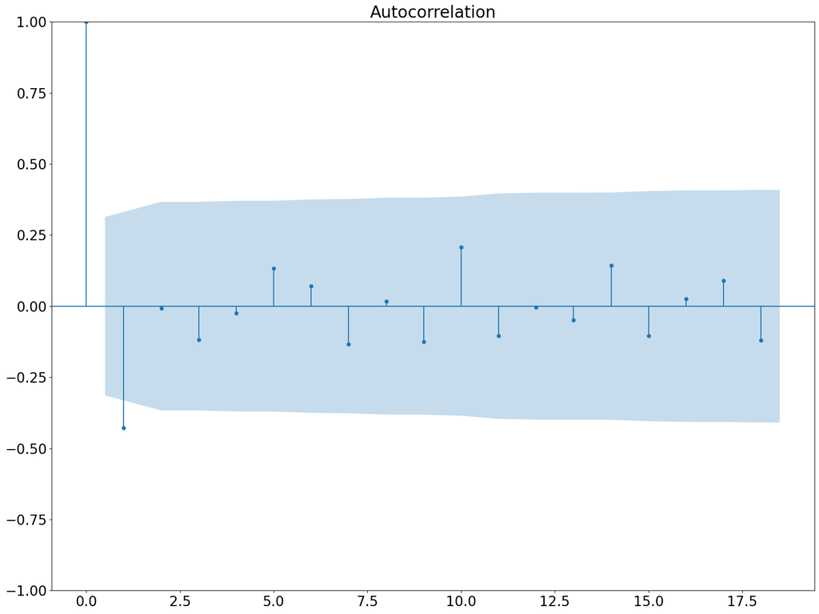

```python
plot_pacf(df_canada['Return'][1:] , lags = 18)
plot_acf(df_canada['Return'][1:] , lags = 18)
plt.show()
```

**By see the pacf and acf plots we can have these pairs of orders for ARIMA model :- \ (1,0,0) , (1,0,1) , (3,0,0) , (3,0,1) , (4,0,0) , (4,0,1)**